# Segmentação de Clientes usando Análise RFM

Reinaldo Zezela

2022-07-09

## Resumo

No presente Post, vamos explorar alguns conceitos e análises relecionados com **RFM**. Vamos abordar, o que é **RFM** e como podemos usar esses parâmetros para segmentar os clientes e orientar as campanhas de marketing com base no RFM scores*.

Portanto, vamos começar por definir o que é **RFM** e por que é importante.

## 1.0 Introdução

### 1.1 O que é RFM?

**RFM** é um método usado para analisar o valor do cliente. **RFM** significa Recente, Frequência e Valor Monetário, isto é *Recency, Frequency and Monetary*.

*RECENCY*: Há quanto tempo o cliente visitou nosso site ou há quanto tempo um cliente comprou o nosso produto?

**Frequência**: com que frequência eles visitam ou com que frequência compram?

**Valor Monetário**: quanta receita recebemos da visita deles ou quanto eles gastam quando compram?

### 1.2 Qual é a importância de Análise RFM?

A **Análise RFM** é uma estrutura de marketing usada para entender e analisar o comportamento do cliente com base nos três factores acima descritos, Recente, Frequência e Valor Monetário (RFM).

A *Análise RFM* ajudará as empresas a segmentar sua base de clientes em diferentes grupos homogêneos para que possam dedicar-se e direccionar diferentes estratégias de marketing para cada grupo.

### 1.3 Aplicação de RFM em uma base de dados

Portanto, vamos nos concentrar em segmentar os clientes com base nos seus comportamentos de compras, isto é vamos determinar os parâmetros RFM de cada cliente tendo em conta as suas transacções históricas.

## 2.0 Análise RFM

Carregar os dados

```r
# carregar os dados
library(tidyverse) # para manipulação de dados
retails_dat <- read.csv(file = "00_data/OnlineRetail.csv")

retails_dat %>%
    glimpse()
```

```
## Rows: 541,909
## Columns: 8
## $ InvoiceNo   <chr> "536365", "536365", "536365", "536365", "536365", "536365"~
## $ StockCode   <chr> "85123A", "71053", "84406B", "84029G", "84029E", "22752", ~
## $ Description <chr> "WHITE HANGING HEART T-LIGHT HOLDER", "WHITE METAL LANTERN~
## $ Quantity    <int> 6, 6, 8, 6, 6, 2, 6, 6, 6, 32, 6, 6, 8, 6, 6, 3, 2, 3, 3, ~
## $ InvoiceDate <chr> "12/1/2010 8:26", "12/1/2010 8:26", "12/1/2010 8:26", "12/~
## $ UnitPrice   <dbl> 2.55, 3.39, 2.75, 3.39, 3.39, 7.65, 4.25, 1.85, 1.85, 1.69~
## $ CustomerID  <int> 17850, 17850, 17850, 17850, 17850, 17850, 17850, 17850, 17~
## $ Country     <chr> "United Kingdom", "United Kingdom", "United Kingdom", "Uni~
```

### 2.1 Examinar os dados

Examinando os dados notamos que, a variável *InvoiceDate* deve ser transformada para o tipo *date()*. E optamos por criar uma nova variável *created_at* para manipularmos os dados.

Também, vamos converter o tipo de dados da variável *CustomerID* para *factor*, visto que este não será usado para efeitos de cálculos.

```r
# create new data type
retails_dat$created_at <- lubridate::mdy_hm(retails_dat$InvoiceDate)

# convert to date type
retails_dat$created_at <- as.Date(retails_dat$created_at)

retails_dat <-
    retails_dat %>%
    mutate_if(is.character, as.factor)

retails_dat$CustomerID <- as.factor(retails_dat$CustomerID)

retails_dat %>%
    glimpse()
```

```
## Rows: 541,909
## Columns: 9
## $ InvoiceNo   <fct> 536365, 536365, 536365, 536365, 536365, 536365, 536365, 53~
## $ StockCode   <fct> 85123A, 71053, 84406B, 84029G, 84029E, 22752, 21730, 22633~
## $ Description <fct> "WHITE HANGING HEART T-LIGHT HOLDER", "WHITE METAL LANTERN~
## $ Quantity    <int> 6, 6, 8, 6, 6, 2, 6, 6, 6, 32, 6, 6, 8, 6, 6, 3, 2, 3, 3, ~
## $ InvoiceDate <fct> 12/1/2010 8:26, 12/1/2010 8:26, 12/1/2010 8:26, 12/1/2010 ~
## $ UnitPrice   <dbl> 2.55, 3.39, 2.75, 3.39, 3.39, 7.65, 4.25, 1.85, 1.85, 1.69~
## $ CustomerID  <fct> 17850, 17850, 17850, 17850, 17850, 17850, 17850, 17850, 17~
## $ Country     <fct> United Kingdom, United Kingdom, United Kingdom, United Kin~
## $ created_at  <date> 2010-12-01, 2010-12-01, 2010-12-01, 2010-12-01, 2010-12-0~
```

Também, podemos ter o resumo das principais estatísticas.

```r
retails_dat %>% summary()
```

```
##    InvoiceNo        StockCode                                  Description
##  573585 :  1114   85123A :  2313   WHITE HANGING HEART T-LIGHT HOLDER:  2369
##  581219 :   749   22423  :  2203   REGENCY CAKESTAND 3 TIER          :  2200
##  581492 :   731   85099B :  2159   JUMBO BAG RED RETROSPOT           :  2159
##  580729 :   721   47566  :  1727   PARTY BUNTING                     :  1727
##  558475 :   705   20725  :  1639   LUNCH BAG RED RETROSPOT           :  1638
##  579777 :   687   84879  :  1502   ASSORTED COLOUR BIRD ORNAMENT     :  1501
##  (Other):537202   (Other):530366   (Other)                           :530315
##     Quantity                   InvoiceDate       UnitPrice
##  Min.   :-80995.00   10/31/2011 14:41:  1114   Min.   :-11062.06
##  1st Qu.:     1.00   12/8/2011 9:28  :   749   1st Qu.:     1.25
##  Median :     3.00   12/9/2011 10:03 :   731   Median :     2.08
##  Mean   :     9.55   12/5/2011 17:24 :   721   Mean   :     4.61
##  3rd Qu.:    10.00   6/29/2011 15:58 :   705   3rd Qu.:     4.13
##  Max.   : 80995.00   11/30/2011 15:13:   687   Max.   : 38970.00
##                      (Other)         :537202
##    CustomerID               Country         created_at
##  17841  :  7983   United Kingdom:495478   Min.   :2010-12-01
##  14911  :  5903   Germany       :  9495   1st Qu.:2011-03-28
##  14096  :  5128   France        :  8557   Median :2011-07-19
##  12748  :  4642   EIRE          :  8196   Mean   :2011-07-04
##  14606  :  2782   Spain         :  2533   3rd Qu.:2011-10-19
##  (Other):380391   Netherlands   :  2371   Max.   :2011-12-09
##  NA's   :135080   (Other)       : 15279
```

Entretanto, há $135080$ registos cujo *CustomerID* possui valores nulos. Portanto, estes serão removidos.

```r
# excluir observacoes sem CustomerID
retails_dat <- retails_dat[complete.cases(retails_dat$CustomerID), ]

retails_dat %>%
    glimpse()
```

```
## Rows: 406,829
## Columns: 9
## $ InvoiceNo   <fct> 536365, 536365, 536365, 536365, 536365, 536365, 536365, 53~
## $ StockCode   <fct> 85123A, 71053, 84406B, 84029G, 84029E, 22752, 21730, 22633~
## $ Description <fct> "WHITE HANGING HEART T-LIGHT HOLDER", "WHITE METAL LANTERN~
## $ Quantity    <int> 6, 6, 8, 6, 6, 2, 6, 6, 6, 32, 6, 6, 8, 6, 6, 3, 2, 3, 3, ~
## $ InvoiceDate <fct> 12/1/2010 8:26, 12/1/2010 8:26, 12/1/2010 8:26, 12/1/2010 ~
## $ UnitPrice   <dbl> 2.55, 3.39, 2.75, 3.39, 3.39, 7.65, 4.25, 1.85, 1.85, 1.69~
## $ CustomerID  <fct> 17850, 17850, 17850, 17850, 17850, 17850, 17850, 17850, 17~
## $ Country     <fct> United Kingdom, United Kingdom, United Kingdom, United Kin~
## $ created_at  <date> 2010-12-01, 2010-12-01, 2010-12-01, 2010-12-01, 2010-12-0~
```

### 2.2 Análise Exploratória de Dados

Vamos verificar o nível de vendas para cada categoria de produto e as respectivas quantidades vendidas. Portanto, vamos usar o pacote *ggplot2* para visualizar os dados.

```r
top50_produto_categoria_tbl <-
    retails_dat %>%
    group_by(Description) %>%
    summarise(Total_Amount = sum(UnitPrice * Quantity)) %>%
    arrange(desc(Total_Amount)) %>%
    # top50 categoria de produto
    head(n = 50) %>%
    ungroup()

top50_produto_categoria_tbl
```

```
## # A tibble: 50 x 2
##    Description                          Total_Amount
##    <fct>                                       <dbl>
##  1 "REGENCY CAKESTAND 3 TIER"                132870.
##  2 "WHITE HANGING HEART T-LIGHT HOLDER"       93824.
##  3 "JUMBO BAG RED RETROSPOT"                  83237.
##  4 "PARTY BUNTING"                            67688.
##  5 "POSTAGE"                                  66710.
##  6 "ASSORTED COLOUR BIRD ORNAMENT"            56499.
##  7 "RABBIT NIGHT LIGHT"                       51138.
##  8 "CHILLI LIGHTS"                            45937.
##  9 "PAPER CHAIN KIT 50'S CHRISTMAS "          41500.
## 10 "PICNIC BASKET WICKER 60 PIECES"           39620.
## # ... with 40 more rows
```

Graficamente, representamos de seguinte modo:

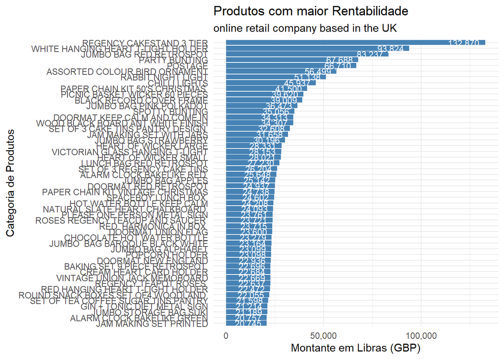

```r
p <- ggplot(data = top50_produto_categoria_tbl, aes(x = reorder(Description, Total_Amount), y = Total_Amount)) +
  geom_col(fill="steelblue") +
    # Outside bars
    # geom_text(aes(label=percent), vjust=-0.3, size=3.5) +
    geom_text(aes(label = scales::comma(Total_Amount, accuracy = 1)), vjust = 0.5, hjust = 1.2, color = "white", size = 3) +
    labs( x = "Categoria de Produtos",
          y = "Montante em Libras (GBP)",
          title = "Produtos com maior Rentabilidade",
          subtitle = "online retail company based in the UK") +
        theme_minimal() +
    scale_y_continuous(labels = scales::label_comma())

# Horizontal bar plot
p + coord_flip()
```

Quantidade vendida por cada categoria de produto

```r
top50_quantidade_produto_tbl <-
    retails_dat %>%
    group_by(Description) %>%
    summarise(total_quantity = sum(Quantity)) %>%
    arrange(desc(total_quantity)) %>%
    head(n = 50) %>%
    ungroup()

top50_quantidade_produto_tbl
```

```
## # A tibble: 50 x 2
##    Description                          total_quantity
##    <fct>                                         <int>
##  1 "WORLD WAR 2 GLIDERS ASSTD DESIGNS"           53215
##  2 "JUMBO BAG RED RETROSPOT"                     45066
##  3 "ASSORTED COLOUR BIRD ORNAMENT"               35314
##  4 "WHITE HANGING HEART T-LIGHT HOLDER"          34147
##  5 "PACK OF 72 RETROSPOT CAKE CASES"             33409
##  6 "POPCORN HOLDER"                              30504
##  7 "RABBIT NIGHT LIGHT"                          27094
##  8 "MINI PAINT SET VINTAGE "                     25880
##  9 "PACK OF 12 LONDON TISSUES "                  25321
## 10 "PACK OF 60 PINK PAISLEY CAKE CASES"          24163
## # ... with 40 more rows
```

Graficamente:

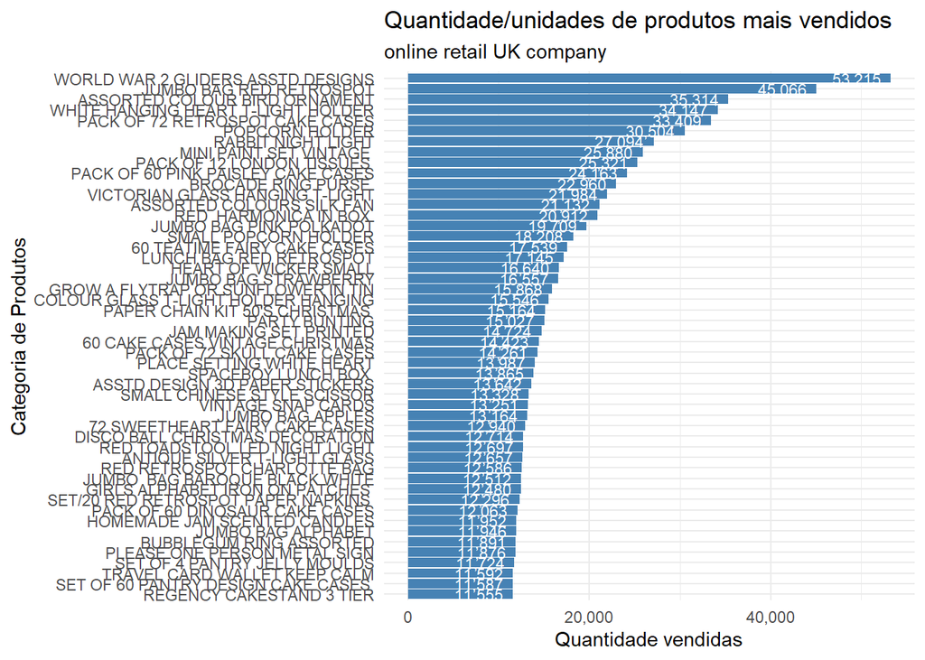

```r
p <- ggplot(data = top50_quantidade_produto_tbl, aes(x = reorder(Description, total_quantity), y = total_quantity)) +
  geom_col(fill="steelblue") +
    # Outside bars
    # geom_text(aes(label=percent), vjust=-0.3, size=3.5) +
    geom_text(aes(label = scales::comma(total_quantity, accuracy = 1)), vjust = 0.5, hjust = 1.2, color = "white", size = 3) +
    labs( x = "Categoria de Produtos",
          y = "Quantidade vendidas",
          title = "Quantidade/unidades de produtos mais vendidos",
          subtitle = "online retail UK company") +
        theme_minimal() +
    scale_y_continuous(labels = scales::label_comma())

# Horizontal bar plot
p + coord_flip()
```

Como podem ter notado, a quantidade/unidades de produtos vendidos não traz *insights* para o negócio, ou seja não é possivel saber se estes são os produtos mais solicitados pelos diversos clientes. Este resultado pode ser influenciado por alguns clientes que efectuam grandes compras. Em outras palavras, isso é diferente de dizer que há muita procura por aqueles produtos ou que existem muitos clientes procurando por esses produtos.

Dito isso, o nosso foco será identificar os produtos com maior rotactividade, isto é aqueles produtos que são mais solicitados pelos clientes. Portanto, vamos nos basear no número de pedidos ou ordens de compras feitas pelos clientes. Para tal, vamos usar a função *count()* em **R**.

```r
# os produtos mais solicitados pelos clientes
top50_requested_product_tbl <-
    retails_dat %>%
    count(Description) %>%
    arrange(desc(n)) %>%
    head(50)

top50_requested_product_tbl
```

```
##                            Description    n
## 1   WHITE HANGING HEART T-LIGHT HOLDER 2070
## 2             REGENCY CAKESTAND 3 TIER 1905
## 3              JUMBO BAG RED RETROSPOT 1662
## 4        ASSORTED COLOUR BIRD ORNAMENT 1418
## 5                        PARTY BUNTING 1416
## 6              LUNCH BAG RED RETROSPOT 1358
## 7    SET OF 3 CAKE TINS PANTRY DESIGN  1232
## 8                              POSTAGE 1196
## 9              LUNCH BAG  BLACK SKULL. 1126
## 10     PACK OF 72 RETROSPOT CAKE CASES 1080
## 11     PAPER CHAIN KIT 50'S CHRISTMAS  1029
## 12                      SPOTTY BUNTING 1029
## 13          LUNCH BAG SPACEBOY DESIGN  1021
## 14                 LUNCH BAG CARS BLUE 1012
```

[output cut: 36 more lines]

Graficamente:

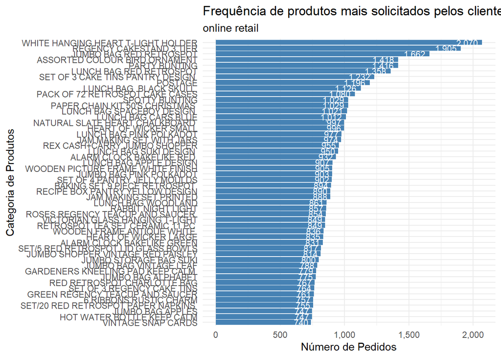

```r
p <- ggplot(data = top50_requested_product_tbl, aes(x = reorder(Description, n), y = n)) +
  geom_col(fill="steelblue") +
    # Outside bars
    # geom_text(aes(label=percent), vjust=-0.3, size=3.5) +
    geom_text(aes(label = scales::comma(n, accuracy = 1)), vjust = 0.5, hjust = 1.2, color = "white", size = 3) +
    labs( x = "Categoria de Produtos",
          y = "Número de Pedidos",
          title = "Frequência de produtos mais solicitados pelos clientes",
          subtitle = "online retail") +
        theme_minimal() +
    scale_y_continuous(labels = scales::label_comma())

# Horizontal bar plot
p + coord_flip()
```

Da mesma forma, podemos verificar qual região possui maior base de clientes.

```r
customer_base_country_tbl <-
    retails_dat %>%
    distinct(CustomerID, Country) %>%
    count(Country) %>%
    arrange(desc(n))

customer_base_country_tbl
```

```
##                 Country    n
## 1        United Kingdom 3950
## 2               Germany   95
## 3                France   87
## 4                 Spain   31
## 5               Belgium   25
## 6           Switzerland   21
## 7              Portugal   19
## 8                 Italy   15
## 9               Finland   12
## 10              Austria   11
## 11               Norway   10
## 12            Australia    9
## 13      Channel Islands    9
## 14              Denmark    9
```

[output cut: 23 more lines]

Graficamente:

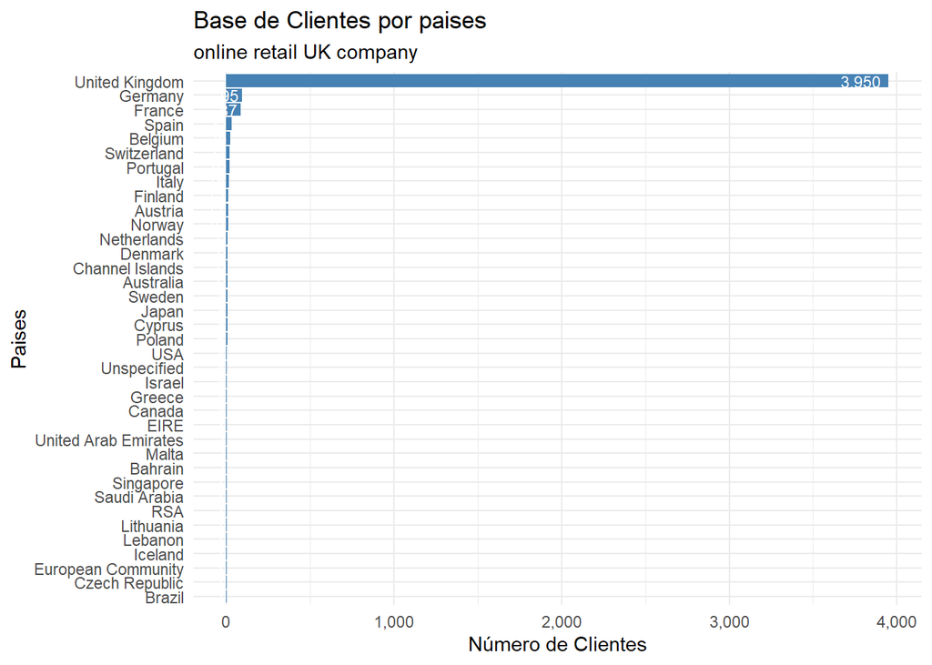

```r
p <- ggplot(data = customer_base_country_tbl, aes(x = reorder(Country, n), y = n)) +
  geom_col(fill="steelblue") +
    # Outside bars
    # geom_text(aes(label=percent), vjust=-0.3, size=3.5) +
    geom_text(aes(label = scales::comma(n, accuracy = 1)), vjust = 0.5, hjust = 1.2, color = "white", size = 3) +
    labs( x = "Paises",
          y = "Número de Clientes",
          title = "Base de Clientes por paises",
          subtitle = "online retail UK company") +
        theme_minimal() +
    scale_y_continuous(labels = scales::label_comma())

# Horizontal bar plot
p + coord_flip()
```

### 2.3 Determinar os parâmetros *RFM* em R

Primeiro, vamos definir o periódo em análise bem como a **data de referência** para as análises.

```r
range(retails_dat$created_at)
```

```
## [1] "2010-12-01" "2011-12-09"
```

O output mostra transacções desde *“2010-12-01”* para *“2011-12-09”*. Então, vamos considerar data de referência para análise o dia *2011-12-10*.

Data de Referência:

```r
# date of analysis
retails_dat$date_of_analysis <- as.Date('2011-12-10')
```

Portanto, vamos calcular a diferença entre a data de referência, *2011-12-10* e as datas dos pedidos de compras.

```r
# calcular a diferença entre a date de referência e as datas dos pedidos de compras
retails_dat$days_since <-
    as.numeric(
        retails_dat$date_of_analysis - retails_dat$created_at
    )

retails_dat %>%
    glimpse()
```

```
## Rows: 406,829
## Columns: 11
## $ InvoiceNo        <fct> 536365, 536365, 536365, 536365, 536365, 536365, 53636~
## $ StockCode        <fct> 85123A, 71053, 84406B, 84029G, 84029E, 22752, 21730, ~
## $ Description      <fct> "WHITE HANGING HEART T-LIGHT HOLDER", "WHITE METAL LA~
## $ Quantity         <int> 6, 6, 8, 6, 6, 2, 6, 6, 6, 32, 6, 6, 8, 6, 6, 3, 2, 3~
## $ InvoiceDate      <fct> 12/1/2010 8:26, 12/1/2010 8:26, 12/1/2010 8:26, 12/1/~
## $ UnitPrice        <dbl> 2.55, 3.39, 2.75, 3.39, 3.39, 7.65, 4.25, 1.85, 1.85,~
## $ CustomerID       <fct> 17850, 17850, 17850, 17850, 17850, 17850, 17850, 1785~
## $ Country          <fct> United Kingdom, United Kingdom, United Kingdom, Unite~
## $ created_at       <date> 2010-12-01, 2010-12-01, 2010-12-01, 2010-12-01, 2010~
## $ date_of_analysis <date> 2011-12-10, 2011-12-10, 2011-12-10, 2011-12-10, 2011~
## $ days_since       <dbl> 374, 374, 374, 374, 374, 374, 374, 374, 374, 374, 374~
```

Portanto, agora podemos calcular os parâmetros RFM.

*Recency (recente)* é a diferença entre a **data de referência** e a data em que o cliente fez a última compra, isto é a compra mais recente.

Vamos obter a *Frequency (Frequência)* somando o número de pedidos feitos por cliente.

*Monetary (Valor Monetário)* será calculado somando o valor total gasto por cada cliente durante o periódo em análise.

```r
# analysis
customer_analysis_tbl <-
    retails_dat %>%
    group_by(CustomerID) %>%
    summarise(
        recency = min(days_since),
        first_purchase = max(days_since),
        frequency = n(),
        monetary = sum(Quantity*UnitPrice)
    ) %>%
    filter(monetary > 0) %>%
    ungroup()


customer_analysis_tbl %>%
    glimpse()
```

```
## Rows: 4,317
## Columns: 5
## $ CustomerID     <fct> 12347, 12348, 12349, 12350, 12352, 12353, 12354, 12355,~
## $ recency        <dbl> 3, 76, 19, 311, 37, 205, 233, 215, 23, 34, 2, 8, 53, 28~
## $ first_purchase <dbl> 368, 359, 19, 311, 297, 205, 233, 215, 326, 34, 151, 33~
## $ frequency      <int> 182, 31, 73, 17, 95, 4, 58, 13, 59, 131, 19, 254, 129, ~
## $ monetary       <dbl> 4310.00, 1797.24, 1757.55, 334.40, 1545.41, 89.00, 1079~
```

Vamos examinar os dados da tabela *customer_analysis_tbl*.

```r
# summary statistics
customer_analysis_tbl %>%
    summary()
```

```
##    CustomerID      recency      first_purchase   frequency
##  12347  :   1   Min.   :  1.0   Min.   :  1    Min.   :   1.0
##  12348  :   1   1st Qu.: 17.0   1st Qu.:116    1st Qu.:  18.0
##  12349  :   1   Median : 50.0   Median :253    Median :  43.0
##  12350  :   1   Mean   : 90.9   Mean   :226    Mean   :  94.1
##  12352  :   1   3rd Qu.:139.0   3rd Qu.:332    3rd Qu.: 103.0
##  12353  :   1   Max.   :374.0   Max.   :374    Max.   :7983.0
##  (Other):4311
##     monetary
##  Min.   :     2.9
##  1st Qu.:   302.7
##  Median :   658.3
##  Mean   :  1925.7
##  3rd Qu.:  1627.1
##  Max.   :279489.0
##
```

O output mostra que o seguinte: - **Recency (Recente)**: há clientes que não fazem compra há mais de $374$ dias, portanto o periódo mais longo. E, o valor mediano é de $50$ dias; - **Frequency (Frequência)**: há clientes que efectuaram próximo de $8,000$ pedidos durante os 12 meses. O valor mediano é de $43$ pedidos por cliente. - **Monetary (Valor Monetário)**: há um cliente com o valor total de compra de $279,489.00$ GBP nos 12 meses do periódo em análise. O valor mediano gasto por cliente é de $658.30$ GBP. Também, mostra que *75%* dos clientes gastam menos de $1,627.10$ GBP. - **first_purchase**: será útil para identificar os novos clientes.

Nós usamos o valor mediano, visto que o valor médio pode ser influenciado pelos valores extremos.

Portanto, vamos usar o histograma para visualizar graficamente os parâmetros RFM.

#### 2.3.1 Histograma de parâmetro *Recency* (Recente)

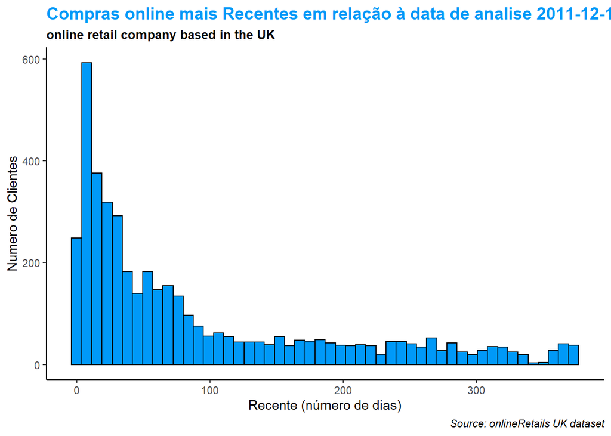

```r
# Histogram Recency
ggplot(data = customer_analysis_tbl, aes(x = recency)) +
    geom_histogram(bins = 50, color = "#000000", fill = "#0099F8") +
    labs(
        title = "Compras online mais Recentes em relação à data de analise 2011-12-10",
        subtitle = "online retail company based in the UK",
        caption = "Source: onlineRetails UK dataset",
        x = "Recente (número de dias)",
        y = "Numero de Clientes"
    ) +
    theme_classic() +
    theme(
        plot.title = element_text(color = "#0099F8", size = 14, face = "bold"),
        plot.subtitle = element_text(size = 10, face = "bold"),
        plot.caption = element_text(face = "italic")
    )
```

Verifica-se que, há muitos clientes que realizam compras dentro de 03 meses. Contudo, também há clientes que não fazem compras há mais de 01 ano. Desta forma, podemos identificar os clientes e direcioná-los de forma diferente. Mas, é muito cedo para dizer apenas com o parâmetro de *Recency*.

#### 2.3.2 Histograma de parâmetro *Frequency* (Frequência)

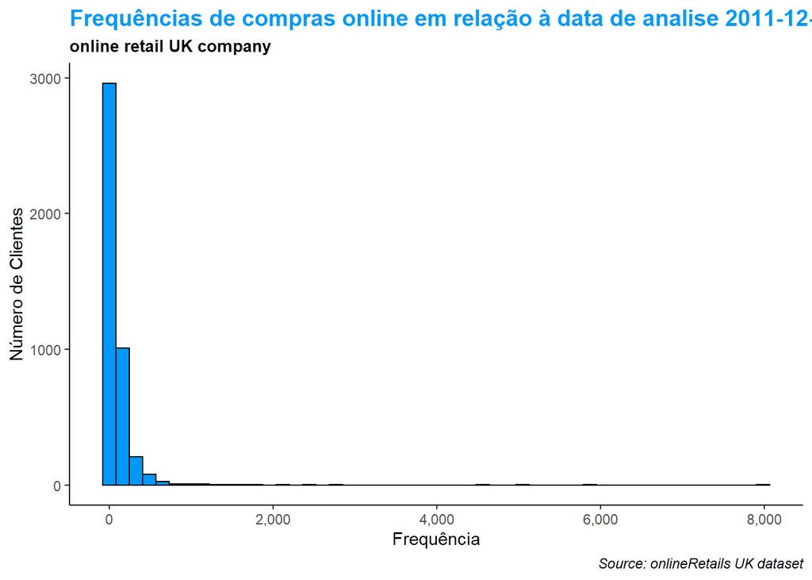

```r
# Histogram Frequency
ggplot(data = customer_analysis_tbl, aes(x = frequency)) +
    geom_histogram(bins = 50, color = "#000000", fill = "#0099F8") +
    labs(
        title = "Frequências de compras online em relação à data de analise 2011-12-10",
        subtitle = "online retail UK company",
        caption = "Source: onlineRetails UK dataset",
        x = "Frequência",
        y = "Número de Clientes"
    ) +
    scale_x_continuous(labels = scales::comma) +
    # scale_x_log10() +
    theme_classic() +
    theme(
        plot.title = element_text(color = "#0099F8", size = 14, face = "bold"),
        plot.subtitle = element_text(size = 10, face = "bold"),
        plot.caption = element_text(face = "italic")
    )
```

O ouptup mostra, uma difereça abismal entre as frequências de compras dos clientes. Por exemplo, um cliente com $8,000$ pedidos é um valor extremamente elevado e distante da maioria dos clientes.

#### 2.3.3 Histograma de parâmetro *Monetary* (Valor Monetário)

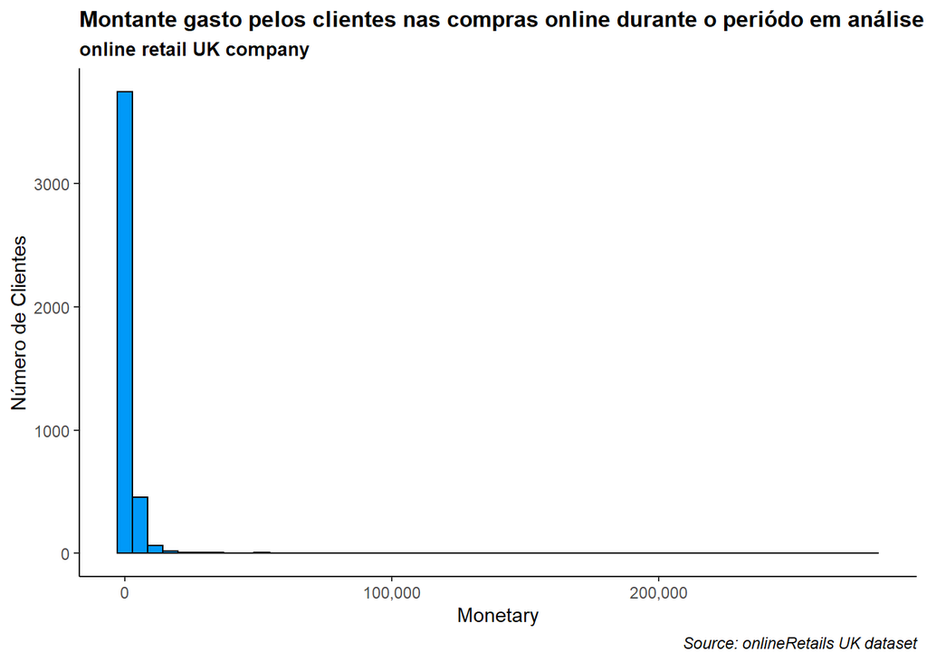

```r
# Histogram Monetary
ggplot(data = customer_analysis_tbl, aes(x = monetary)) +
    geom_histogram(bins = 50, color = "#000000", fill = "#0099F8") +
    labs(
        title = "Montante gasto pelos clientes nas compras online durante o periódo em análise",
        subtitle = "online retail UK company",
        caption = "Source: onlineRetails UK dataset",
        x = "Monetary",
        y = "Número de Clientes"
    ) +
    scale_x_continuous(labels = scales::comma) +
    # scale_x_log10() +
    theme_classic() +
    theme(
        plot.title = element_text(size = 12, face = "bold"),
        plot.subtitle = element_text(size = 10, face = "bold"),
        plot.caption = element_text(face = "italic")
    )
```

Aqui, também mostra o quanto a distribuição é afectada pelos valores extremos. Portanto, a maioria dos clientes gastou menos de $1,000$ GBP durante o periodo em análise.

#### 2.3.4 Scatter Plot

Quando temos mais de duas variáveis, escolhemos um gráfico de dispersão para analisar.

Recency Vs frequency

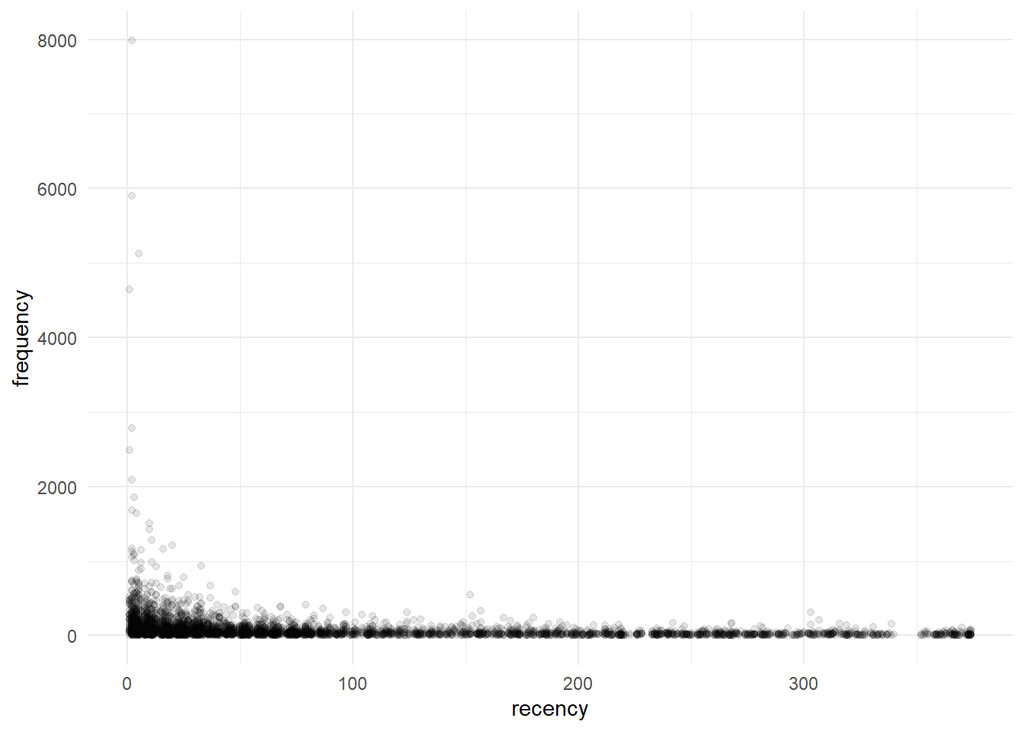

```r
ggplot(data = customer_analysis_tbl, aes(x = recency, y = frequency)) +
    geom_point(alpha = 1/10) +
    scale_x_continuous(labels = scales::comma) +
    # scale_x_log10() +
    theme_minimal()
```

Podemos constatar que, os clientes cujo *Recency* é inferior a um mês têm a **frequência** elevada, ou seja, os clientes compram mais quando o seu valor de *Recency* é menor.

Frequency Vs Monetary

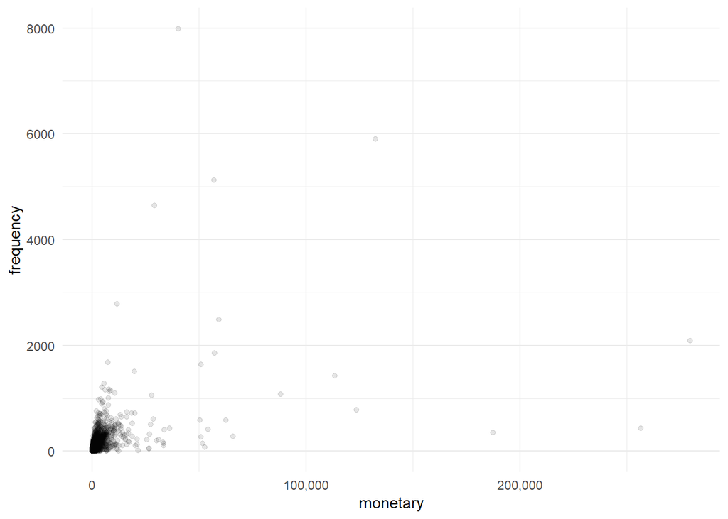

```r
ggplot(data = customer_analysis_tbl, aes(x = monetary, y = frequency)) +
    geom_point(alpha = 1/10) +
    scale_x_continuous(labels = scales::comma) +
    # scale_x_log10() +
    # scale_y_log10() +
    theme_minimal()
```

Recency Vs Monetary

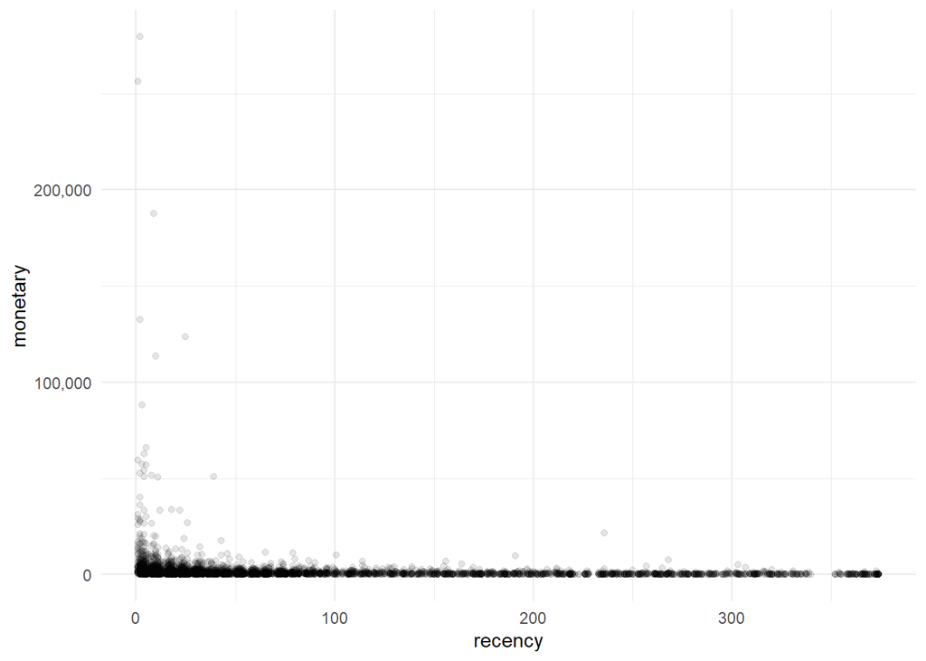

```r
ggplot(data = customer_analysis_tbl, aes(x = recency, y = monetary), color = frequency) +
    geom_point(alpha = 1/10) +
    scale_y_continuous(labels = scales::comma) +
    # scale_x_log10() +
    # scale_y_log10() +
    theme_minimal()
```

### 2.4 Como Segmentar os Clientes

Não podemos chegar a nenhuma conclusão com base em apenas os parâmetros **RFM** de forma independente. Portanto, temos que tomar em conta todos os 03 factores.